# Neural network walk through

## General overview

This section will talk through a practical implementation of a neural network in base Python - feel free to copy the code and implement in your own projects after completing it. With that out the way - let's begin!

Neural networks - although immensely powerful - are not as theoretically fearsome as they may at first seem. As we've previously discussed, a network consists of the following componenents:

- A series of distinct layers
- Each layer contains between 1 and N neurons
- Each neuron is a basic multidimensional linear model (including an intercept) that sums the product of it's inputs and it's internal coefficients (weights) so as to return a number - which is feed to it's activation function
- A neurons output is defined as the output of the neurons linear model, transformed via an activation function
- Common activations include linear, sigmoid, tanh and reclu
- This output - plus the outputs of all other neurons on the layer - form the input into each of the next layers neurons
- The only exception to this is the first layer - which is fed an observations of the training data as there is no previous layer
- A consequence of this is that the number of coefficients per neuron in a layer is either the number of neurons in the previous layer + 1 (for the bias/intercept) or equal to dimensionality of the input data
- It is therefore intuitive that in the case of regression, the final layer of the network will always contain a single neuron - as we require a single output
- A neural network is "trained" by finding the partial derivative of the output of the network relative to each of the weights/linear model coefficients of the networks neurons through a method called backpropagation.
- Once the partial derivitve is known, the weights can be slightly adjusted - via gradient descent - and therefore make the network more accurate (i.e. reduce the error between network output and training response)

Take a moment to reread the above and make sure you are comfortable with the concepts and general flow. If not - don't worry. We will break it down through a practical example.

## Data preparation

A neural network is designed to solve a problem. Let's say for example that we want to predict the stock price tomorrow, based on what the stock price was 1 year ago. We will feed the stock price from 1 year ago into our neural network, and evaluate it's performance relative to the price today.

Therefore, to build our neural network we would require:

- Our input signal (which we will colour blue - for example the stock price 365 days ago)
- Our response signal (which we will colour red - the stock price today)

The code box below will create these signals

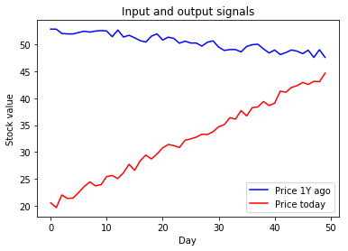

```python
#We import the libraries we will need for the example
import numpy as np
import matplotlib.pyplot as mp
from numpy.random import uniform

#We create 50 observations of our input (features) and output (response) data
training_features = np.arange(55,50,-0.1) +np.random.uniform(-1,1,50)-2
training_response = np.arange(0,25,0.5)+np.random.uniform(-1,1,50)+20

#we plot our data
mp.plot(training_features,'b',label = 'Price 1Y ago')
mp.plot(training_response,'r',label = 'Price today')

#we create graph aesthetics
mp.title("Input and output signals")
mp.xlabel("Day")
mp.ylabel("Stock value")
mp.legend(loc='lower right')
```

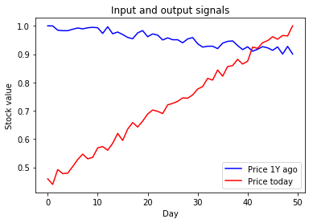

```python
#we now normalize the data to have a range of between 0 and 1
max_features = np.max(training_features)
max_response  = np.max(training_response)

std_features    = (training_features/max_features)
std_response = (training_response/max_response)

#we plot our data
mp.plot(std_features,'b',label = 'Price 1Y ago')
mp.plot(std_response,'r',label = 'Price today')

#we create graph aesthetics
mp.title("Input and output signals")
mp.xlabel("Day")
mp.ylabel("Stock value")
mp.legend(loc='lower right')
```

## Defining a Neural Network

Now that we have created our input and output signals, we need to create our neural network - from scratch! As the main intention of this section is to educate, rather than performance, we will simplify the creation of these neural network with some strict boundary conditions:

- Our network will be able to handle inputs of any dimensionality
- Our network will be able to have unlimited neurons per layers, and unlimited layers
- Our network will only have sigmoid or linear activation functions
- Our network will update it's weights after every training sample - i.e. it will operate on a batch size of one

The code box below will define both our neural network, and any auxillary global functions we may need in order to solve our problem (e.g. a sigmoid function). Take your time to read through it, and read the comments of each line of code. Don't worry if it seems overwhelming - we will step through it in a later codeblock

```python
#########################################################
#MATHEMATICAL FUNCTIONS REQUIRED FOR NETWORK
#########################################################

#This is a simple linear activation function
def linear(inputs):
    return float(inputs)

#This is a sigmoid activation function
def sigmoid(inputs):
    return float(1/(1 + np.exp(-inputs)))

#This a linear deriviative function
def linear_d(inputs):
    return float(inputs)

#This is the sigmoid derivitive function
def sigmoid_d(inputs):
    return inputs*(1-inputs)

#########################################################
#NEURAL NETWORK CLASS
#########################################################
#This section will contain the neural network class
#Each section will be commented, containing it's function and explaining how it works
#This will be called, step by step, in a later codeblock - so don't worry to skip ahead if it's useful

class Neural_Network:

    #This function initializes the neural network
    def __init__(self,input_dim,hidden,activation):
        self.input_dim     = input_dim #This is the dimensionality of the input - i.e. how many features per observation
        self.hidden        = hidden #This is an array, with each entry representing the number of neurons in that layer
        self.activation    = activation #This is an array, with each entry representing the activation function of that layer
        self.network       = self.create_network() #This calls the internal function that creates the neural network

    #This function creates the network
    def create_network(self):

        network = list() #we will store the details of our network in a list

        i = 0
        for j in self.hidden: #we step through the hidden layers

            #this determines the number of weights per neuron in the layer - if the first layer then
            #it is the input dimensions + 1 for the intercept(or bias) - else it is the size of the previous
            #layer + 1 for the bias
            weights = self.input_dim+1 if i == 0 else self.hidden[i-1]+1
            activation = self.activation[i]        #this sets the activation function for the layer

            #the code below creates our hidden layer as an array of dictionaries - with one dictionary per neuron
            #this contains the activation function of the neuron, and an array containing the weights
            # weights are randomly generated between -1 and 1
            hidden_layer = [{'activation' :(activation),
                             'weights':[uniform(high=1,low=-1) for i in range(weights)]} for i in range(self.hidden[i])]

            #we the newly created layer to our network
            network.append(hidden_layer)

            i+=1

        return network

    #this function calculates the input into each of the neurons activation function
    def neuron_activation(self,neuron_inputs, neuron_weights):

        #the first weight is set aside as the intercept or bias
        bias = neuron_weights[0]
        #the rest of the weights are summed as a dot product with the neuron inputs
        non_bias = np.dot(neuron_inputs,neuron_weights[1:])
        #the output (i.e. input to the function) is the sum of the dot product and the bias
        function_input = non_bias + bias

        return function_input

    #this function feeds an observation through the network so as to generate an output
    #it will return an array containing the output of every layer of the network
    #the first entry in the array will be the input to the network
    def feed_forward(self,training_sample):

        #this declares the input to the layer to be the training sample
        layer_input = training_sample
        #this stores the input of the first layer in an array
        layered_outputs = [training_sample]

        i = 0
        #we loop iteratively through each layer in the network
        for layer in self.network:

            #we set the output of the current layer to a blank array
            layer_output = []

            #we loop through each neuron in the layer
            for neuron in layer:
                #we first calculate the input into the neurons activation function
                neuron_input      = self.neuron_activation(neuron_inputs = layer_input,neuron_weights = neuron['weights'])

                #we then feed this input into the activation function
                if(neuron['activation'] == 'linear'):
                    neuron_output     = linear(neuron_input)
                elif(neuron['activation'] == 'sigmoid'):
                    neuron_output     = sigmoid(neuron_input)

                #we append the neuron output to our array of layer outputs
                layer_output.append(neuron_output)

            #we store our layer output in our array of outputs
            layered_outputs.append(layer_output)
            #we reset the input to the next layer to be equal to the input of this layer
            layer_input = layer_output

            i+=1

        return (layered_outputs)

    #this function calculates the partial derivitive of the neural network relative to the output
    #this is perhaps the most complicated function within our neural network - so take your time to understand
    #each step. The general method will be to start at the determine how the output of the network changes as
    #as we adjust any of the weights of the network. We do this backwards - starting with the final layer and
    #working our way back to the first. Throughout this process we calculate partial derivitives -i.e. we assume
    #all other weights are held constant when we determine each of the weights partial derivitives
    #the output of this function will be a dictionary of dictionaries

    def partial(self,model_outputs):

        #we get the number of layers - and reverse the order so as to step through backwards
        layers = list(range(0,len(self.hidden)))
        layers.sort(reverse=True)

        #Step through each of the layers backwards
        layer_count = 0
        for layer in layers:
            neuron_count = 0
```

```python
            #We check if it is the final layer of the network
            if(layer_count == 0):

                temp_dict = dict()  #we prepare our temporary output for this layer

                for neuron in self.network[layer]: #we loop through the neurons in the layer
                    #please note as this is a regression network we assume there will be a single neuron
                    #in the output layer

                    if(neuron['activation'] == 'linear'):
                        #this lists the partial derivitives of the last layer if the function is linear
                        #the exact mathematics of will not be described in this section
                        #this is the partial for the output in respect to an adjustment in the bias term
                        d_bias          = 1
                        #this is the partial for the output in respect to an adjustment in any of the weights
                        d_weights       = np.array(model_outputs[layer])
                        #this is the partial for the output in respect to any adjustment of an input into this layer
                        d_input         = list(map(linear_d,neuron['weights'][1:]))

                        #this section stores the partials in a dictionary, and appends it to the final output
                        temp_dict[neuron_count] = {'Bias' : d_bias, 'Weight' : list(d_weights), 'Input' : d_input}
                        layer_details   = { layer : temp_dict}

                    if(neuron['activation'] == 'sigmoid'):
                        #this lists the partial derivitives of the last layer if the function is sigmoid
                        #the exact mathematics of will not be described in this section
                        sig_input       = model_outputs[layer+1][neuron_count]
                        d_bias          = sigmoid_d(sig_input)
                        d_weights       = np.array(outputs[layer])*sigmoid_d(sig_input)
                        d_input         = np.array(neuron['weights'][1:])*sigmoid_d(sig_input)

                        #this section stores the partials in a dictionary, and appends it to the final output
                        temp_dict       = {neuron_count: {'Bias' : d_bias, 'Weight' : list(d_weights), 'Input' : d_input}}
                        layer_details   = { layer : temp_dict}

                    neuron_count = neuron_count + 1

                layer_details[layer] = temp_dict

            #this section is for every layer barring the last layer
            else:

                temp_dict = dict()

                for neuron in self.network[layer]:

                    #Each layer barring the last layer needs a scaling factor so as to calculate it's partial derivities
                    #this is because any adjustment to a weight at this stage won't directly alter the final output -
                    #rather it alters the input into the next layer. For example, let's say the partial derivitive for a neuron
                    #in the second to last layer is 2, while the partial derivitive in regards to the inputs into the final
                    #layer is 3. Then the ultimate partial of the second to last layer neuron would be 6.

                    Factor_numerator = 0 #this initializes the numerator and denominator of the next layer
                    Factor_denom     = 0

                    #We will calculate what the factor is by averaging the partials (in respect to a change in input)
                    #for each neuron in the next layer
                    for I in layer_details[layer+1]:
                        #we first sum the partials in respect to each neurons input
                        Factor_numerator += np.sum(layer_details[layer+1][I]['Input'][neuron_count])
                        #We average this over the number of neurons impacted
                        Factor_denom += 1
                    Factor = Factor_numerator/Factor_denom

                    if(neuron['activation'] == 'linear'):
                        #this calculates the partial in respect to the bias, weights and input for every neuron in
                        #the layer
                        d_bias          = 1*Factor
                        d_weights       = np.array(model_outputs[layer])*Factor
                        d_input         = list(np.array(list(map(linear_d,neuron['weights'][1:])))*Factor)

                        #this section stores the partials in a dictionary, and appends it to the final output
                        temp_dict[neuron_count] = {'Bias' : d_bias, 'Weight' : np.array(d_weights), 'Input' : d_input}

                    if(neuron['activation'] == 'sigmoid'):
                        #this calculates the partial in respect to the bias, weights and input for every neuron in
                        #the layer
                        sig_input       = model_outputs[layer+1][neuron_count]
                        d_bias          = sigmoid_d(sig_input)*Factor
                        d_weights       = np.array(model_outputs[layer])*sigmoid_d(sig_input)*Factor
                        d_input         = np.array(neuron['weights'][1:])*sigmoid_d(sig_input)*Factor

                        #this section stores the partials in a dictionary, and appends it to the final output
                        temp_dict[neuron_count] = {'Bias' : d_bias, 'Weight' : np.array(d_weights), 'Input' : d_input}

                    neuron_count = neuron_count + 1
                layer_details[layer] = temp_dict
            layer_count = layer_count + 1

        return layer_details

    #this function updates the weights of the model based on the partial derivitive
    def update_weights(self,partial,target,prediction,learning_rate):

        #we first determine is our estimate is too high, or too low
        loss = target - prediction
        #depending on the above we either plan to increase our output, or decrease it
        factor = learning_rate if loss > 0 else -learning_rate
```

```python
        layer_count = 0
        for layer in self.network:   #we loop through each layer in the model
            neuron_count = 0
            for neuron in layer: #we loop through each neuron in the layer
                #we then adjust each weight in the neural network by multiplying it's partial by our
                #sign adjusted learning factor, i.e. if it has a positive partial, and we wish to decrease
                #the output - then we will subtract a small amount off of it - the converse is also true
                neuron['weights'][1:] += np.array(partial[layer_count][neuron_count]['Weight'])*factor
                neuron['weights'][0]  += np.array(partial[layer_count][neuron_count]['Bias'])*factor
                neuron_count +=1
            layer_count += 1
        return
```

## Exploring the neural network class

Let us explore the neural network class we have just created. We will do this by creating a simple 3x3x1 neural network and exploring it's properties

```python
#Let us create a neural network of 3x3x1 with linear activation functions
model = Neural_Network(input_dim=1,activation=["linear","linear","linear"],hidden=[3,3,1])
```

```python
#let's print out each of the layers we have created and explore the activation functions and weights for each
#it's important to remember that the first weight refers to the bias, or intercept, term
layer_count = 0

for layer in model.network:
    print("Current layer is: " + str(layer_count))

    for neuron in layer:
        print(neuron)

    layer_count = layer_count + 1
```

```
Current layer is: 0
{'activation': 'linear', 'weights': [0.7859198257557929, 0.909682497446213]}
{'activation': 'linear', 'weights': [-0.12870142536312978, -0.6171921795456847]}
{'activation': 'linear', 'weights': [0.16010060720008368, -0.514652761541285]}
Current layer is: 1
{'activation': 'linear', 'weights': [0.5713021600466452, -0.47696213054450975, 0.25165632856429143, 0.2533021601422618]}
{'activation': 'linear', 'weights': [0.28266185531025845, -0.9783071505825296, -0.8928230585511174, 0.7125262020454632]}
{'activation': 'linear', 'weights': [-0.7976013295837132, 0.6748415483982211, 0.3533185988013714, 0.9319209550608851]}
Current layer is: 2
{'activation': 'linear', 'weights': [0.9662493379563635, -0.5353969412726736, 0.6689950358523324, -0.9649639834893775]}
```

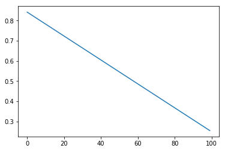

```python
#let's explore what it predicts organically for a variety of inputs
x_sample = range(0,100,1)
y_sample = []

for step in x_sample:
    y_sample.append(model.feed_forward(step)[-1])

mp.plot(y_sample)
```

```python
#we can also investigate the partial derivitives of any neuron using the partial internal class function
#Let's investigate the partial derivitives of the first neuron in the very first layer as an example
model.partial(model_outputs=model.feed_forward(5))[0][0]
```

```
{'Bias': -0.3501054500828704,
 'Weight': array(-1.75052725),
 'Input': [-0.318484800200916]}
```

```python
#let us now sense check one of these results. The bias term from any neuron in the middle layer would adjust that neurons
#output by 1 if incremented by 1 - i.e. the partial derivitive of that neuron in respect to the bias is 1. The inputs into
#the next layer would have a partial derivitive equal to the weights of that layer - i.e. a unit increase in the input would
#increase the output by the weight value. Therefore the partial in respect to any bias in the middle layer would be equal to
#the weight in the last layer - let us confirm.

#we extract the weight terms of the final layer
print(model.network[2][0]['weights'][1:])

#we extract the bias partials terms of the second layer - as can be seen they are equivalent to the weight terms
#of the final layer
for I in range(0,3):
    print(model.partial(model.feed_forward(0))[1][I]['Bias'])
```

[output not shown]

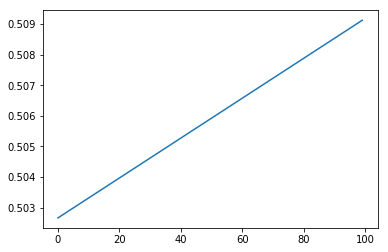

```python
#let's see if we can train our network to consistantly predict out a value of 0.5!
x_sample = range(0,100,1)

#we train through a 100 cycles
for epochs in range(0,400):
    for step in x_sample:
        prediction = model.feed_forward(step/100)
        partial    = model.partial(prediction)
        target     = 0.5
        output     = sum(prediction[-1])
        model.update_weights(learning_rate=0.01,partial=partial,prediction=output,target=target)


#we plot our final predictions
y_sample = []

for step in x_sample:
    y_sample.append(model.feed_forward(step/100)[-1])

mp.plot(y_sample)
```

## Training our Neural Network

We will then plot both the average training error as a function of the epoch, and the final neural network predictions.

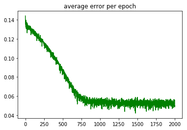

```python
#################################################################################################
#MODEL CREATION AND HYPER PARAMETERS
#################################################################################################
model_build = Neural_Network(input_dim=1,activation=["linear","linear","linear"],hidden=[5,5,1]) #we build the model
learning_rate = 0.001 #we set the learning rate
errors = []           #we create an empty array to store the average errors of each epoch
prediction = 'none'   #we initialize an empty prediction


#################################################################################################
#MODEL TRAINING
#################################################################################################
#we loop through a 1000 epochs of the training data
for i in range(0,2000):

    #we intialize an empty error to store the errors of each prediction
    #these will be averaged and then stored in the "errors" array
    error = []

    #we shuffle the data for each iteration of the 1000 iterations of the training
    randomize = np.arange(len(std_features))
    np.random.shuffle(randomize)
    training_x = std_features[randomize]
    training_y = std_response[randomize]


    count = 0

    #we loop through each instance of the training data
    for J in training_x:

        goal        = training_y[count]                #we set the goal for the training to be the response data
        outputs     = model_build.feed_forward(J)      #we make a predictions based on the training data
        partial     = model_build.partial(outputs)     #we calculate the partial derivitives of the network
        prediction  = sum(outputs[-1])                 #we determine what the output of the network is

        #we update the model weights
        model_build.update_weights(partial=partial,learning_rate=learning_rate,prediction=prediction,target=goal)
        #we append the error for this example to the error array
        error.append(abs(prediction-goal))
        count = count+1

    #we append the mean error to the global array of errors
    errors.append(np.mean(error))

#################################################################################################
#ERROR PLOTTING AND FINAL PREDICTIONS
#################################################################################################
#we plot the error as a function of the epoch - as can be seen on the resulting plot the average error
#decreases dramatically over the training epochs

axes = mp.gca()
mp.title('average error per epoch')
mp.plot(errors,'g')

#we make our final predictions with our trained network
predictions = []
for J in std_features:
    outputs = model_build.feed_forward(J)
    predictions.append(sum(outputs[-1]))
predictions = np.array(predictions)
```

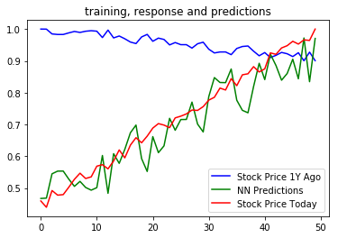

```python
#################################################################################################
#PLOTTING OF FINAL RESULTS
#################################################################################################
mp.title('training, response and predictions')
mp.plot(std_features,'b',label = 'Stock Price 1Y Ago')
mp.plot(predictions,'g',label = 'NN Predictions')
mp.plot(std_response,'r',label = 'Stock Price Today')
mp.legend()
```